# Майнор "Интеллектуальный анализ данных"

# Курс "Современные методы машинного обучения"

# Лабораторная работа №1. Image Classification.

В данной лабораторной работе вам предлагается обучить модель на основе нейронной сети для распознавания рукописных букв английского алфавита.

## Данные

Данные представлены двумя датасетами: обучающим (`train`) и тестовым (`test`). Изображения для каждого датасета находятся в `images.zip`.

Обучающая выборка состоит из 65000 изображений - по 2500 изображений для каждой буквы.  
Тестовая выборка состоит из 13000 изображений - по 500 изображений для каждой буквы.

Все изображения - монохромные (но в формате RGB), размерности $28 \times 28$ пикселей, в формате JPEG. В названии каждого файла содержатся буква, которая представлена на изображении, и уникальный номер изображения: `a_00002.jpg`.

**NB:** Все изображения представлены в перевернутом виде, для корректного отображения их нужно сначала транспонировать.

```python
import numpy as np
import matplotlib.pyplot as plt
```

```python
pic = plt.imread('images/train/a/a_00002.jpg')
print(pic.shape)
```

```
(28, 28, 3)
```

```python
pic = np.transpose(pic, axes=(1, 0, 2))
```

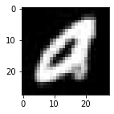

```python
plt.figure(figsize=(2,2))
plt.imshow(pic)
plt.show()
```

## Основные задания

Ваша задача - создать и обучить модель на основе нейронной сети, которая будет предсказывать букву на картинке.  
Обучение необходимо проводить на данных из `train`, качество модели проверять на данных из `test`.  
Целевая метрика - accuracy.  
Для моделирования необходимо использовать `pytorch`.

### Задание 1

*Вес в общей оценке - 0.35*

1. Постройте и обучите модели с 2-мя и 3-мя полносвязными (dense) скрытыми слоями.  
   При моделировании необходимо попробовать разные параметры нейронной сети - число нейронов на каждом слое, learning rate, batch size, функции активации, регуляризации и т.д. Оцените качество моделей с различными параметрами, проведите сравнительный анализ.
2. Для наилучшей модели постройте confusion matrix результатов предсказаний модели на тестовых данных.  
   Насколько равномерно обучилась ваша модель? Приведите буквы с самой лучшей и с самой худшей точностью детекции.
3. Найдите 10 пар букв, которые чаще всего путаются между собой, дайте возможное объяснение. Приведите примеры с картинками, которые были детектированы с ошибкой.
4. Возьмите первую букву вашей фамилии и укажите её точность детекции. С какими буквами ваша модель чаще всего путает эту букву?

#### Import

```python
%matplotlib inline
%config InlineBackend.figure_format = 'retina'

from torch import nn
import numpy as np
import torch
import torchvision
from torchvision import datasets, transforms
import matplotlib.pyplot as plt
from time import time
from PIL import Image
import os
from tqdm.notebook import tqdm
import torch.nn.functional as F
```

#### Preparing the dataset

```python
class AlphabetDataset(torch.utils.data.Dataset):
    def __init__(self, path):
        composer = transforms.Compose([transforms.Lambda(lambda x: np.transpose(x, axes=(1, 0, 2))),
                                      transforms.ToTensor(),
                                      transforms.Normalize((0.5, 0.5, 0.5), (0.5, 0.5, 0.5)),
                                      transforms.Grayscale(num_output_channels=1),
                                      transforms.Lambda(lambda x: x.float())])
        self.x = torch.Tensor()
        self.y = list()
        self.len = 0
        for root, subdirs, files in os.walk(path):
            for file in files:
                if os.path.splitext(file)[1].lower() == '.jpg':
                    self.len += 1
                    self.y.append(ord(file[0]) - ord('a'))
                    pic = composer(Image.open(os.path.join(root, file)))
                    self.x = torch.cat((self.x, pic), 0)
        self.y = torch.Tensor(self.y)

    def __getitem__(self, index):
        return self.x[index] , self.y[index]

    def __len__(self):
        return self.len
```

```python
trainset = AlphabetDataset("images/train/")
valset = AlphabetDataset("images/test/")
```

```python
trainloader = torch.utils.data.DataLoader(trainset, batch_size=16, shuffle=True, num_workers=2)
valloader = torch.utils.data.DataLoader(valset, batch_size=16, shuffle=True, num_workers=2)
```

#### Check data

```python
dataiter = iter(trainloader)
images, labels = dataiter.next()
print(type(images))
print(images.shape)
print(labels.shape)
```

```
<class 'torch.Tensor'>
torch.Size([16, 28, 28])
torch.Size([16])
```

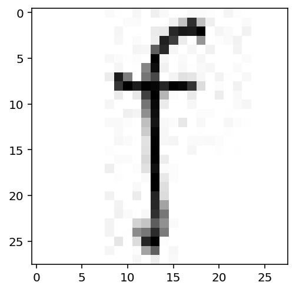

```python
plt.imshow(images[0].numpy().squeeze(), cmap='gray_r');
```

#### Defining The Neural Network

```python
def view_classify(img, ps):
    ''' Function for viewing an image and it's predicted classes.
    '''
    ps = ps.data.numpy().squeeze()

    fig, (ax1, ax2) = plt.subplots(figsize=(6,9), ncols=2)
    ax1.imshow(img.resize_(1, 28, 28).numpy().squeeze())
    ax1.axis('off')
    ax2.barh(np.arange(26), ps)
    ax2.set_aspect(0.1)
    ax2.set_yticks(np.arange(26))
    ax2.set_yticklabels(np.arange(26))
    ax2.set_title('Class Probability')
    ax2.set_xlim(0, 1.1)
    plt.tight_layout()
```

```python
def test_func(batch_size, epochs, lr, hidden_size, criterion):
    print(f"\nbatch_size={batch_size}, epochs={epochs}, lr={lr}, hidden_size={hidden_size}, criterion={type(criterion)}")
    input_size = 784

    output_size = 26
    model = nn.Sequential(nn.Linear(input_size, hidden_size),
                      nn.ReLU(),
                      nn.Linear(hidden_size, output_size),
                      nn.ReLU(),
                      nn.LogSoftmax(dim=1))

    trainloader = torch.utils.data.DataLoader(trainset, batch_size=batch_size, shuffle=True, num_workers=2)
    valloader = torch.utils.data.DataLoader(valset, batch_size=batch_size, shuffle=True, num_workers=2)

    optimizer = torch.optim.SGD(model.parameters(), lr=lr)
    time0 = time()
    for e in range(epochs):
        running_loss = 0
        for images, labels in trainloader:
            # Flatten MNIST images into a 784 long vector
            images = images.view(images.shape[0], -1)

            # Training pass
            optimizer.zero_grad()

            output = model(images)
            loss = criterion(output, labels.long())

            #This is where the model learns by backpropagating
            loss.backward()

            #And optimizes its weights here
            optimizer.step()

            running_loss += loss.item()
    print("Training Time (in minutes) =",(time()-time0)/60)
    correct_count, all_count = 0, 0
    for images,labels in valloader:
        for i in range(len(labels)):
            img = images[i].view(1, 784)
            # Turn off gradients to speed up this part
            with torch.no_grad():
                logps = model(img)

            # Output of the network are log-probabilities, need to take exponential for probabilities
            ps = torch.exp(logps)
            probab = list(ps.numpy()[0])
            pred_label = probab.index(max(probab))
            true_label = labels.numpy()[i]
            if(true_label == pred_label):
              correct_count += 1
            all_count += 1

    print("Number Of Images Tested =", all_count)
    print("Model Accuracy =", (correct_count/all_count))
```

```python
criterion = nn.NLLLoss()
for batch_size in (16, 32, 64):
    for epochs in (5, 10, 15):
        for lr in (0.003, 0.009, 0.06):
            for hidden_size in (128, 256, 512, 1024):
                   test_func(batch_size, epochs, lr, hidden_size, criterion)
```

```
batch_size=16, epochs=5, lr=0.003, hidden_size=128, criterion=<class 'torch.nn.modules.loss.NLLLoss'>
Training Time (in minutes) = 0.5163778344790141
Number Of Images Tested = 13000
Model Accuracy = 0.6576923076923077

batch_size=16, epochs=5, lr=0.003, hidden_size=256, criterion=<class 'torch.nn.modules.loss.NLLLoss'>
Training Time (in minutes) = 0.6323240200678507
Number Of Images Tested = 13000
Model Accuracy = 0.6576923076923077

batch_size=16, epochs=5, lr=0.003, hidden_size=512, criterion=<class 'torch.nn.modules.loss.NLLLoss'>
Training Time (in minutes) = 0.8264066179593405
Number Of Images Tested = 13000
Model Accuracy = 0.7265384615384616

batch_size=16, epochs=5, lr=0.003, hidden_size=1024, criterion=<class 'torch.nn.modules.loss.NLLLoss'>
Training Time (in minutes) = 1.3653159181276957
Number Of Images Tested = 13000
Model Accuracy = 0.741

batch_size=16, epochs=5, lr=0.009, hidden_size=128, criterion=<class 'torch.nn.modules.loss.NLLLoss'>
Training Time (in minutes) = 0.6491059343020121
Number Of Images Tested = 13000
Model Accuracy = 0.805076923076923

batch_size=16, epochs=5, lr=0.009, hidden_size=256, criterion=<class 'torch.nn.modules.loss.NLLLoss'>
Training Time (in minutes) = 0.8167306542396545
Number Of Images Tested = 13000
Model Accuracy = 0.8058461538461539

batch_size=16, epochs=5, lr=0.009, hidden_size=512, criterion=<class 'torch.nn.modules.loss.NLLLoss'>
Training Time (in minutes) = 1.0210623582204184
Number Of Images Tested = 13000
Model Accuracy = 0.8183076923076923

batch_size=16, epochs=5, lr=0.009, hidden_size=1024, criterion=<class 'torch.nn.modules.loss.NLLLoss'>
Training Time (in minutes) = 1.4127836624781291
Number Of Images Tested = 13000
Model Accuracy = 0.8387692307692308

```

[output cut: 484 more lines]

```

batch_size=64, epochs=15, lr=0.06, hidden_size=256, criterion=<class 'torch.nn.modules.loss.NLLLoss'>
Training Time (in minutes) = 0.6249750852584839
Number Of Images Tested = 13000
Model Accuracy = 0.8836153846153846

batch_size=64, epochs=15, lr=0.06, hidden_size=512, criterion=<class 'torch.nn.modules.loss.NLLLoss'>
Training Time (in minutes) = 0.8077458620071412
Number Of Images Tested = 13000
Model Accuracy = 0.8929230769230769

batch_size=64, epochs=15, lr=0.06, hidden_size=1024, criterion=<class 'torch.nn.modules.loss.NLLLoss'>
Training Time (in minutes) = 1.1999011874198913
Number Of Images Tested = 13000
Model Accuracy = 0.7508461538461538
```

Из этих данных видно, что оптимальное значение batch_size=32 (значения почти такие же как при 16, но скорость обучения выше). Так же я выбрал epochs=10 тк судя по данным за это количество модель успевает обучиться. Значения lr я хочу взять выше чем я брал, поэтому выбираю 0.03, 0.06, 0.09. В hidden_size я решил отказаться от 128, потому что оно показывало худшие результаты

```python
criterion = nn.NLLLoss()
for lr in (0.03, 0.06, 0.09):
    for hidden_size in (256, 512, 1024):
            test_func(32, 10, lr, hidden_size, criterion)
```

```
batch_size=32, epochs=10, lr=0.03, hidden_size=256, criterion=<class 'torch.nn.modules.loss.NLLLoss'>
Training Time (in minutes) = 0.642825973033905
Number Of Images Tested = 13000
Model Accuracy = 0.8689230769230769

batch_size=32, epochs=10, lr=0.03, hidden_size=512, criterion=<class 'torch.nn.modules.loss.NLLLoss'>
Training Time (in minutes) = 0.8849215785662333
Number Of Images Tested = 13000
Model Accuracy = 0.8882307692307693

batch_size=32, epochs=10, lr=0.03, hidden_size=1024, criterion=<class 'torch.nn.modules.loss.NLLLoss'>
Training Time (in minutes) = 1.2953896959622702
Number Of Images Tested = 13000
Model Accuracy = 0.89

batch_size=32, epochs=10, lr=0.06, hidden_size=256, criterion=<class 'torch.nn.modules.loss.NLLLoss'>
Training Time (in minutes) = 0.6965126514434814
Number Of Images Tested = 13000
Model Accuracy = 0.8826923076923077

batch_size=32, epochs=10, lr=0.06, hidden_size=512, criterion=<class 'torch.nn.modules.loss.NLLLoss'>
Training Time (in minutes) = 0.8884952982266744
Number Of Images Tested = 13000
Model Accuracy = 0.8790769230769231

batch_size=32, epochs=10, lr=0.06, hidden_size=1024, criterion=<class 'torch.nn.modules.loss.NLLLoss'>
Training Time (in minutes) = 1.3308351397514344
Number Of Images Tested = 13000
Model Accuracy = 0.8962307692307693

batch_size=32, epochs=10, lr=0.09, hidden_size=256, criterion=<class 'torch.nn.modules.loss.NLLLoss'>
Training Time (in minutes) = 0.6932381709416707
Number Of Images Tested = 13000
Model Accuracy = 0.8606923076923076

batch_size=32, epochs=10, lr=0.09, hidden_size=512, criterion=<class 'torch.nn.modules.loss.NLLLoss'>
Training Time (in minutes) = 0.8861770709355672
Number Of Images Tested = 13000
Model Accuracy = 0.8905384615384615

batch_size=32, epochs=10, lr=0.09, hidden_size=1024, criterion=<class 'torch.nn.modules.loss.NLLLoss'>
Training Time (in minutes) = 1.295003612836202
Number Of Images Tested = 13000
Model Accuracy = 0.8690769230769231
```

Решил проверить что будет если сделать hidden_size= 2048

```python
criterion = nn.NLLLoss()
for lr in (0.03, 0.06, 0.09):
    test_func(32, 10, lr, 2048, criterion)
```

```
batch_size=32, epochs=10, lr=0.03, hidden_size=2048, criterion=<class 'torch.nn.modules.loss.NLLLoss'>
Training Time (in minutes) = 2.2679911454518638
Number Of Images Tested = 13000
Model Accuracy = 0.7345384615384616

batch_size=32, epochs=10, lr=0.06, hidden_size=2048, criterion=<class 'torch.nn.modules.loss.NLLLoss'>
Training Time (in minutes) = 2.2725548068682353
Number Of Images Tested = 13000
Model Accuracy = 0.8427692307692307

batch_size=32, epochs=10, lr=0.09, hidden_size=2048, criterion=<class 'torch.nn.modules.loss.NLLLoss'>
Training Time (in minutes) = 2.284039858977
Number Of Images Tested = 13000
Model Accuracy = 0.8867692307692308
```

hidden size 2048 показало плохие результаты.

Тогда лучшие результаты при 2 слоях показали при параметрах batch_size=16, epochs=15, lr=0.06, hidden_size=1024 - Accuracy > 0.9

Попробуем изменить функцию активации при этих же параметрах

```python
def test_func2(batch_size, epochs, lr, hidden_size, criterion):
    print(f"\nbatch_size={batch_size}, epochs={epochs}, lr={lr}, hidden_size={hidden_size}, criterion={type(criterion)}")
    input_size = 784

    output_size = 26
    model = nn.Sequential(nn.Linear(input_size, hidden_size),
                      nn.SiLU(),
                      nn.Linear(hidden_size, output_size),
                      nn.SiLU(),
                      nn.LogSoftmax(dim=1))

    trainloader = torch.utils.data.DataLoader(trainset, batch_size=batch_size, shuffle=True, num_workers=2)
    valloader = torch.utils.data.DataLoader(valset, batch_size=batch_size, shuffle=True, num_workers=2)

    optimizer = torch.optim.SGD(model.parameters(), lr=lr)
    time0 = time()
    for e in range(epochs):
        running_loss = 0
        for images, labels in trainloader:
            # Flatten MNIST images into a 784 long vector
            images = images.view(images.shape[0], -1)

            # Training pass
            optimizer.zero_grad()

            output = model(images)
            loss = criterion(output, labels.long())

            #This is where the model learns by backpropagating
            loss.backward()

            #And optimizes its weights here
            optimizer.step()

            running_loss += loss.item()
    print("Training Time (in minutes) =",(time()-time0)/60)
    correct_count, all_count = 0, 0
    for images,labels in valloader:
        for i in range(len(labels)):
            img = images[i].view(1, 784)
            # Turn off gradients to speed up this part
            with torch.no_grad():
                logps = model(img)

            # Output of the network are log-probabilities, need to take exponential for probabilities
            ps = torch.exp(logps)
            probab = list(ps.numpy()[0])
            pred_label = probab.index(max(probab))
            true_label = labels.numpy()[i]
            if(true_label == pred_label):
              correct_count += 1
            all_count += 1

    print("Number Of Images Tested =", all_count)
    print("Model Accuracy =", (correct_count/all_count))
```

```python
criterion = nn.NLLLoss()
test_func2(16, 15, 0.06, 1024, criterion)
```

```
batch_size=16, epochs=15, lr=0.06, hidden_size=1024, criterion=<class 'torch.nn.modules.loss.NLLLoss'>
Training Time (in minutes) = 3.9342362801233928
Number Of Images Tested = 13000
Model Accuracy = 0.9012307692307693
```

Полученные результаты, хоть и чуть чуть, но все же лучше, чем с активатором ReLU

Я думаю, что это лучший результат, для модели с двумя слоями, поэтому перейдем к моделям с 3 слоями.

```python
def test_func3(batch_size, epochs, lr, hidden_size, criterion):
    print(f"\nbatch_size={batch_size}, epochs={epochs}, lr={lr}, hidden_size={hidden_size}, criterion={type(criterion)}")
    input_size = 784

    output_size = 26
    model = nn.Sequential(nn.Linear(input_size, hidden_size[0]),
                      nn.ReLU(),
                      nn.Linear(hidden_size[0], hidden_size[1]),
                      nn.ReLU(),
                      nn.Linear(hidden_size[1], output_size),
                      nn.ReLU(),
                      nn.LogSoftmax(dim=1))

    trainloader = torch.utils.data.DataLoader(trainset, batch_size=batch_size, shuffle=True, num_workers=2)
    valloader = torch.utils.data.DataLoader(valset, batch_size=batch_size, shuffle=True, num_workers=2)

    optimizer = torch.optim.SGD(model.parameters(), lr=lr)
    time0 = time()
    for e in range(epochs):
        running_loss = 0
        for images, labels in trainloader:
            # Flatten MNIST images into a 784 long vector
            images = images.view(images.shape[0], -1)

            # Training pass
            optimizer.zero_grad()

            output = model(images)
            loss = criterion(output, labels.long())

            #This is where the model learns by backpropagating
            loss.backward()

            #And optimizes its weights here
            optimizer.step()

            running_loss += loss.item()
    print("Training Time (in minutes) =",(time()-time0)/60)
    correct_count, all_count = 0, 0
    for images,labels in valloader:
        for i in range(len(labels)):
            img = images[i].view(1, 784)
            # Turn off gradients to speed up this part
            with torch.no_grad():
                logps = model(img)

            # Output of the network are log-probabilities, need to take exponential for probabilities
            ps = torch.exp(logps)
            probab = list(ps.numpy()[0])
            pred_label = probab.index(max(probab))
            true_label = labels.numpy()[i]
            if(true_label == pred_label):
              correct_count += 1
            all_count += 1

    print("Number Of Images Tested =", all_count)
    print("Model Accuracy =", (correct_count/all_count))
```

```python
criterion = nn.NLLLoss()
for lr in (0.03, 0.06, 0.09):
    for hidden_size1 in (256, 512, 1024):
        for hidden_size2 in (256, 512, 1024):
            test_func3(32, 10, lr, (hidden_size1, hidden_size2), criterion)
```

```
batch_size=32, epochs=10, lr=0.03, hidden_size=(256, 256), criterion=<class 'torch.nn.modules.loss.NLLLoss'>
Training Time (in minutes) = 0.8964866995811462
Number Of Images Tested = 13000
Model Accuracy = 0.8657692307692307

batch_size=32, epochs=10, lr=0.03, hidden_size=(256, 512), criterion=<class 'torch.nn.modules.loss.NLLLoss'>
Training Time (in minutes) = 0.8751697460810344
Number Of Images Tested = 13000
Model Accuracy = 0.8454615384615385

batch_size=32, epochs=10, lr=0.03, hidden_size=(256, 1024), criterion=<class 'torch.nn.modules.loss.NLLLoss'>
Training Time (in minutes) = 1.0493256807327271
Number Of Images Tested = 13000
Model Accuracy = 0.8887692307692308

batch_size=32, epochs=10, lr=0.03, hidden_size=(512, 256), criterion=<class 'torch.nn.modules.loss.NLLLoss'>
Training Time (in minutes) = 1.2012892921765645
Number Of Images Tested = 13000
Model Accuracy = 0.8659230769230769

batch_size=32, epochs=10, lr=0.03, hidden_size=(512, 512), criterion=<class 'torch.nn.modules.loss.NLLLoss'>
Training Time (in minutes) = 1.4063390374183655
Number Of Images Tested = 13000
Model Accuracy = 0.8637692307692307

batch_size=32, epochs=10, lr=0.03, hidden_size=(512, 1024), criterion=<class 'torch.nn.modules.loss.NLLLoss'>
Training Time (in minutes) = 1.672452167669932
Number Of Images Tested = 13000
Model Accuracy = 0.8420769230769231

batch_size=32, epochs=10, lr=0.03, hidden_size=(1024, 256), criterion=<class 'torch.nn.modules.loss.NLLLoss'>
Training Time (in minutes) = 1.6041504859924316
Number Of Images Tested = 13000
Model Accuracy = 0.7956923076923077

batch_size=32, epochs=10, lr=0.03, hidden_size=(1024, 512), criterion=<class 'torch.nn.modules.loss.NLLLoss'>
Training Time (in minutes) = 1.8541302680969238
Number Of Images Tested = 13000
Model Accuracy = 0.7596153846153846

```

[output cut: 79 more lines]

```

batch_size=32, epochs=10, lr=0.09, hidden_size=(1024, 256), criterion=<class 'torch.nn.modules.loss.NLLLoss'>
Training Time (in minutes) = 2.006728410720825
Number Of Images Tested = 13000
Model Accuracy = 0.903

batch_size=32, epochs=10, lr=0.09, hidden_size=(1024, 512), criterion=<class 'torch.nn.modules.loss.NLLLoss'>
Training Time (in minutes) = 2.240596838792165
Number Of Images Tested = 13000
Model Accuracy = 0.9013076923076923

batch_size=32, epochs=10, lr=0.09, hidden_size=(1024, 1024), criterion=<class 'torch.nn.modules.loss.NLLLoss'>
Training Time (in minutes) = 3.361159594853719
Number Of Images Tested = 13000
Model Accuracy = 0.9051538461538462
```

Лучший результат был увеличен при значениях batch_size=32, epochs=10, lr=0.06, hidden_size=(512, 512) до Accuracy = 0.9054615384615384

Попробуем изменить функцию активации

```python
def test_func4(batch_size, epochs, lr, hidden_size, criterion):
    print(f"\nbatch_size={batch_size}, epochs={epochs}, lr={lr}, hidden_size={hidden_size}, criterion={type(criterion)}")
    input_size = 784
    output_size = 26
    model = nn.Sequential(nn.Linear(input_size, hidden_size[0]),
                      nn.SiLU(),
                      nn.Linear(hidden_size[0], hidden_size[1]),
                      nn.SiLU(),
                      nn.Linear(hidden_size[1], output_size),
                      nn.SiLU(),
                      nn.LogSoftmax(dim=1))

    trainloader = torch.utils.data.DataLoader(trainset, batch_size=batch_size, shuffle=True, num_workers=2)
    valloader = torch.utils.data.DataLoader(valset, batch_size=batch_size, shuffle=True, num_workers=2)

    optimizer = torch.optim.SGD(model.parameters(), lr=lr)
    time0 = time()
    for e in range(epochs):
        running_loss = 0
        for images, labels in trainloader:
            # Flatten MNIST images into a 784 long vector
            images = images.view(images.shape[0], -1)

            # Training pass
            optimizer.zero_grad()

            output = model(images)
            loss = criterion(output, labels.long())

            #This is where the model learns by backpropagating
            loss.backward()

            #And optimizes its weights here
            optimizer.step()

            running_loss += loss.item()
    print("Training Time (in minutes) =",(time()-time0)/60)
    correct_count, all_count = 0, 0
    for images,labels in valloader:
        for i in range(len(labels)):
            img = images[i].view(1, 784)
            # Turn off gradients to speed up this part
            with torch.no_grad():
                logps = model(img)

            # Output of the network are log-probabilities, need to take exponential for probabilities
            ps = torch.exp(logps)
            probab = list(ps.numpy()[0])
            pred_label = probab.index(max(probab))
            true_label = labels.numpy()[i]
            if(true_label == pred_label):
              correct_count += 1
            all_count += 1

    print("Number Of Images Tested =", all_count)
    print("Model Accuracy =", (correct_count/all_count))
```

```python
test_func4(32, 10, 0.06, (512, 512), criterion)
```

```
batch_size=32, epochs=10, lr=0.06, hidden_size=(512, 512), criterion=<class 'torch.nn.modules.loss.NLLLoss'>
Training Time (in minutes) = 1.448470985889435
Number Of Images Tested = 13000
Model Accuracy = 0.8996923076923077
```

В этому случае изменение функции активации не улучшило результат. Поэтому дальше я буду работать с параметрами batch_size=32, epochs=10, lr=0.06, hidden_size=(512, 512)

#### ConfusionMatrix

```python
batch_size=32
epochs=10
lr=0.06
hidden_size=(512, 512)
input_size = 784
output_size = 26
model = nn.Sequential(nn.Linear(input_size, hidden_size[0]),
                  nn.ReLU(),
                  nn.Linear(hidden_size[0], hidden_size[1]),
                  nn.ReLU(),
                  nn.Linear(hidden_size[1], output_size),
                  nn.ReLU(),
                  nn.LogSoftmax(dim=1))

trainloader = torch.utils.data.DataLoader(trainset, batch_size=batch_size, shuffle=True, num_workers=2)
valloader = torch.utils.data.DataLoader(valset, batch_size=batch_size, shuffle=True, num_workers=2)

optimizer = torch.optim.SGD(model.parameters(), lr=lr)
time0 = time()
for e in range(epochs):
    running_loss = 0
    for images, labels in trainloader:
        # Flatten MNIST images into a 784 long vector
        images = images.view(images.shape[0], -1)

        # Training pass
        optimizer.zero_grad()

        output = model(images)
        loss = criterion(output, labels.long())

        #This is where the model learns by backpropagating
        loss.backward()

        #And optimizes its weights here
        optimizer.step()

        running_loss += loss.item()
print("Training Time (in minutes) =",(time()-time0)/60)
correct_count, all_count = 0, 0
for images,labels in valloader:
    for i in range(len(labels)):
        img = images[i].view(1, 784)
        # Turn off gradients to speed up this part
        with torch.no_grad():
            logps = model(img)

        # Output of the network are log-probabilities, need to take exponential for probabilities
        ps = torch.exp(logps)
        probab = list(ps.numpy()[0])
        pred_label = probab.index(max(probab))
        true_label = labels.numpy()[i]
        if(true_label == pred_label):
          correct_count += 1
        all_count += 1

print("Number Of Images Tested =", all_count)
print("Model Accuracy =", (correct_count/all_count))
```

```
Training Time (in minutes) = 1.229415762424469
Number Of Images Tested = 13000
Model Accuracy = 0.9033846153846153
```

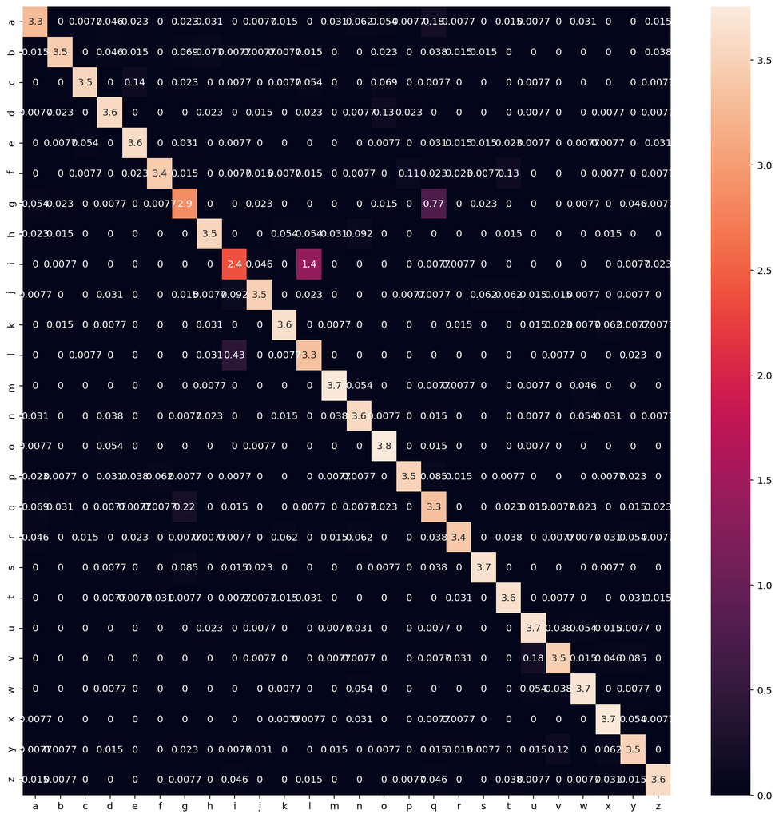

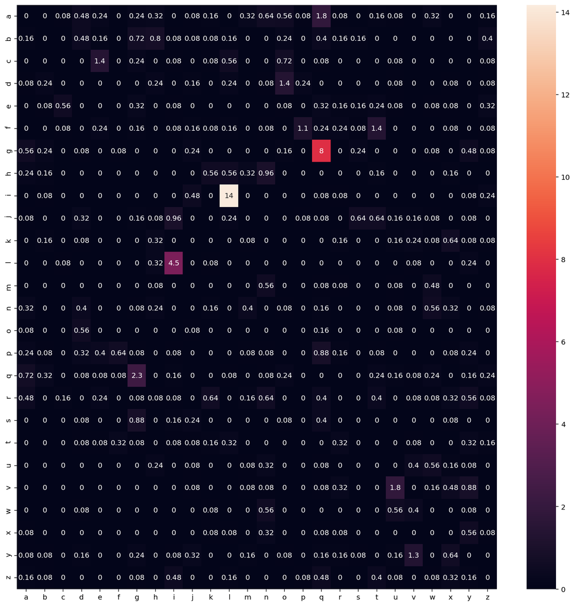

```python
from sklearn.metrics import confusion_matrix
import seaborn as sn
import pandas as pd

y_pred = []
y_true = []

for inputs, labels in valloader:
        inputs = inputs.view(inputs.shape[0], -1)
        output = model(inputs)

        output = (torch.max(torch.exp(output), 1)[1]).data.cpu().numpy()
        y_pred.extend(output)

        labels = labels.data.cpu().numpy()
        y_true.extend(labels)

classes = ('a', 'b', 'c', 'd', 'e', 'f', 'g', 'h', 'i', 'j', 'k', 'l',
        'm', 'n', 'o', 'p', 'q', 'r', 's', 't', 'u', 'v', 'w', 'x', 'y', 'z')

cf_matrix = confusion_matrix(y_true, y_pred)
df_cm = pd.DataFrame(cf_matrix/np.sum(cf_matrix) *100, index = [i for i in classes],
                     columns = [i for i in classes])
plt.figure(figsize = (15,15))
sn.heatmap(df_cm, annot=True)
plt.savefig('output.png')

cf_matrix = confusion_matrix(y_true, y_pred)
for i in range(len(cf_matrix)):
    cf_matrix[i][i] = 0
df_cm = pd.DataFrame(cf_matrix/np.sum(cf_matrix) *100, index = [i for i in classes],
                     columns = [i for i in classes])
plt.figure(figsize = (15,15))
sn.heatmap(df_cm, annot=True)
plt.savefig('output.png')
```

Топ 10 пар букв, которые чаще всего путают:

1)i и l. Это скорее всего происходит из за внешней похожести букв.

2)g и q. Эти буквы так же очень похожи, но g хвостиком выделятеся, поэтому их легче различить.

3)v и u. При небрежном написании могут быть очень похожи.

4)a и q. Фактически отличаются только длинной палочки справа.

5)с и e. Очень похожие буквы отличаются маленькой частью.

6)d и o. При плохом написании d оно похоже на o.

7)f и t. Буквы очень незначительно отличаются только хвостиком сверху.

8)y и v. При небрежном написании y похожа на v.

9)f и p. При написании на одной высоте(а все буквы стоят по центру) отличаются только перемычкой.

10)h и n. При небрежном написании очень похожи.

### Задание 2

*Вес в общей оценке - 0.35*

1. Постройте и обучите модели нейронной сети с 1-м, 2-мя и 3-мя сверточными слоями.  
   Попробуйте различные значения параметров сверток и числа фильтров на каждом слое. Оцените качество моделей с различными параметрами, проведите сравнительный анализ.
2. Для наилучшей конфигурации из предыдущего пункта, сравните, как меняется качество модели при увеличении размера батча при использовании BatchNorm и GroupNorm.

Модель с одним сверточным слоем

```python
model = nn.Sequential(
    nn.Conv2d(in_channels=1, out_channels=32, kernel_size=5),
    nn.MaxPool2d(kernel_size=4),
    nn.Flatten(),
    nn.Linear(6*6*32, 256),
    nn.ReLU(),
    nn.Linear(256, 26),
)

optimizer = torch.optim.SGD(model.parameters(), lr=0.01)

for epoch in range(1, 11):
    for x_train, y_train in tqdm(trainloader):
        x_train = x_train.unsqueeze(1)
        y_pred = model(x_train)
        loss = F.cross_entropy(y_pred, y_train.long())
        loss.backward()
        optimizer.step()
        optimizer.zero_grad()

    if epoch % 2 == 0:
        val_loss = []
        val_accuracy = []
        with torch.no_grad():
            for x_val, y_val in tqdm(valloader):
                x_val = x_val.unsqueeze(1)
                y_pred = model(x_val)
                loss = F.cross_entropy(y_pred, y_val.long())
                val_loss.append(loss.cpu().numpy())
                val_accuracy.extend((torch.argmax(y_pred, dim=-1) == y_val).cpu().numpy().tolist())

        # печатаем метрики
        print(f"Epoch: {epoch}, loss: {np.mean(val_loss)}, accuracy: {np.mean(val_accuracy)}")
```

```
Epoch: 2, loss: 0.3799566626548767, accuracy: 0.8744615384615385
```

```
Epoch: 4, loss: 0.27081242203712463, accuracy: 0.9116153846153846
```

```
Epoch: 6, loss: 0.23746855556964874, accuracy: 0.9206153846153846
```

```
Epoch: 8, loss: 0.22916027903556824, accuracy: 0.924923076923077
```

```
Epoch: 10, loss: 0.2262442409992218, accuracy: 0.925
```

Модель с двумя сверточными слоями

```python
model = nn.Sequential(
    nn.Conv2d(in_channels=1, out_channels=32, kernel_size=3),
    nn.ReLU(),
    nn.MaxPool2d(kernel_size=2, stride=2),

    nn.Conv2d(in_channels=32, out_channels=64, kernel_size=3),
    nn.ReLU(),
    nn.MaxPool2d(kernel_size=2, stride=2),

    nn.Flatten(),
    nn.Linear(5*5*64, 256),
    nn.ReLU(),
    nn.Linear(256, 26),
)


optimizer = torch.optim.SGD(model.parameters(), lr=0.01)

for epoch in range(1, 15):
    for x_train, y_train in tqdm(trainloader):
        x_train = x_train.unsqueeze(1)
        y_pred = model(x_train)
        loss = F.cross_entropy(y_pred, y_train.long())
        loss.backward()
        optimizer.step()
        optimizer.zero_grad()

    if epoch % 2 == 0:
        val_loss = []
        val_accuracy = []
        with torch.no_grad():
            for x_val, y_val in tqdm(valloader):
                x_val = x_val.unsqueeze(1)
                y_pred = model(x_val)
                loss = F.cross_entropy(y_pred, y_val.long())
                val_loss.append(loss.cpu().numpy())
                val_accuracy.extend((torch.argmax(y_pred, dim=-1) == y_val).cpu().numpy().tolist())

        # печатаем метрики
        print(f"Epoch: {epoch}, loss: {np.mean(val_loss)}, accuracy: {np.mean(val_accuracy)}")
```

```
Epoch: 2, loss: 0.327629953622818, accuracy: 0.8967692307692308
```

```
Epoch: 4, loss: 0.24398571252822876, accuracy: 0.9196923076923077
```

```
Epoch: 6, loss: 0.22122368216514587, accuracy: 0.925923076923077
```

```
Epoch: 8, loss: 0.22268155217170715, accuracy: 0.9274615384615384
```

```
Epoch: 10, loss: 0.21821101009845734, accuracy: 0.9281538461538461
```

```
Epoch: 12, loss: 0.24295948445796967, accuracy: 0.9226153846153846
```

```
Epoch: 14, loss: 0.2331710010766983, accuracy: 0.9293076923076923
```

Модель с тремя сверточными слоями

```python
model = nn.Sequential(
    nn.Conv2d(in_channels=1, out_channels=32, kernel_size=3),
    nn.ReLU(),
    nn.MaxPool2d(kernel_size=2, stride=2),

    nn.Conv2d(in_channels=32, out_channels=64, kernel_size=2),
    nn.ReLU(),
    nn.MaxPool2d(kernel_size=2, stride=2),

    nn.Conv2d(in_channels=64, out_channels=64, kernel_size=2),
    nn.ReLU(),

    nn.Flatten(),
    nn.Linear(5*5*64, 256),
    nn.ReLU(),
    nn.Linear(256, 26),
)


optimizer = torch.optim.SGD(model.parameters(), lr=0.01)

for epoch in range(1, 15):
    for x_train, y_train in tqdm(trainloader):
        x_train = x_train.unsqueeze(1)
        y_pred = model(x_train)
        loss = F.cross_entropy(y_pred, y_train.long())
        loss.backward()
        optimizer.step()
        optimizer.zero_grad()

    if epoch % 2 == 0:
        val_loss = []
        val_accuracy = []
        with torch.no_grad():
            for x_val, y_val in tqdm(valloader):
                x_val = x_val.unsqueeze(1)
                y_pred = model(x_val)
                loss = F.cross_entropy(y_pred, y_val.long())
                val_loss.append(loss.cpu().numpy())
                val_accuracy.extend((torch.argmax(y_pred, dim=-1) == y_val).cpu().numpy().tolist())

        # печатаем метрики
        print(f"Epoch: {epoch}, loss: {np.mean(val_loss)}, accuracy: {np.mean(val_accuracy)}")
```

```
Epoch: 2, loss: 0.3882578909397125, accuracy: 0.8732307692307693
```

```
Epoch: 4, loss: 0.26274654269218445, accuracy: 0.9120769230769231
```

```
Epoch: 6, loss: 0.22752149403095245, accuracy: 0.9247692307692308
```

```
Epoch: 8, loss: 0.21710459887981415, accuracy: 0.9297692307692308
```

```
Epoch: 10, loss: 0.2241256684064865, accuracy: 0.928923076923077
```

```
Epoch: 12, loss: 0.22594359517097473, accuracy: 0.9302307692307692
```

```
Epoch: 14, loss: 0.2576196789741516, accuracy: 0.9216923076923077
```

Попробуем разные значения batch size

```python
for batch_size in (16, 32, 64, 128):
    trainloader = torch.utils.data.DataLoader(trainset, batch_size=batch_size, shuffle=True, num_workers=2)
    valloader = torch.utils.data.DataLoader(valset, batch_size=batch_size, shuffle=True, num_workers=2)

    print(f"\n\nbatch_size={batch_size}")

    model = nn.Sequential(
        nn.Conv2d(in_channels=1, out_channels=32, kernel_size=5),
        nn.MaxPool2d(kernel_size=4),
        nn.Flatten(),
        nn.Linear(6*6*32, 256),
        nn.ReLU(),
        nn.Linear(256, 26),
    )

    optimizer = torch.optim.SGD(model.parameters(), lr=0.01)

    for epoch in range(1, 11):
        for x_train, y_train in tqdm(trainloader):
            x_train = x_train.unsqueeze(1)
            y_pred = model(x_train)
            loss = F.cross_entropy(y_pred, y_train.long())
            loss.backward()
            optimizer.step()
            optimizer.zero_grad()

        if epoch % 2 == 0:
            val_loss = []
            val_accuracy = []
            with torch.no_grad():
                for x_val, y_val in tqdm(valloader):
                    x_val = x_val.unsqueeze(1)
                    y_pred = model(x_val)
                    loss = F.cross_entropy(y_pred, y_val.long())
                    val_loss.append(loss.cpu().numpy())
                    val_accuracy.extend((torch.argmax(y_pred, dim=-1) == y_val).cpu().numpy().tolist())

            # печатаем метрики
            print(f"Epoch: {epoch}, loss: {np.mean(val_loss)}, accuracy: {np.mean(val_accuracy)}")
```

```
batch_size=16
```

```
Epoch: 2, loss: 0.31984564661979675, accuracy: 0.8982307692307693
```

```
Epoch: 4, loss: 0.26362115144729614, accuracy: 0.9155384615384615
```

```
Epoch: 6, loss: 0.22883975505828857, accuracy: 0.925
```

```
Epoch: 8, loss: 0.2282637506723404, accuracy: 0.9246153846153846
```

```
Epoch: 10, loss: 0.22728291153907776, accuracy: 0.9246153846153846


batch_size=32
```

```
Epoch: 2, loss: 0.4424053728580475, accuracy: 0.8625384615384616
```

```
Epoch: 4, loss: 0.3160446584224701, accuracy: 0.8997692307692308
```

```
Epoch: 6, loss: 0.2876368463039398, accuracy: 0.9067692307692308
```

```
Epoch: 8, loss: 0.24336077272891998, accuracy: 0.9206153846153846
```

```
Epoch: 10, loss: 0.24658960103988647, accuracy: 0.9191538461538461


batch_size=64
```

```
Epoch: 2, loss: 0.6187859773635864, accuracy: 0.808076923076923
```

```
Epoch: 4, loss: 0.3970358669757843, accuracy: 0.8753846153846154
```

```
Epoch: 6, loss: 0.3296520411968231, accuracy: 0.8992307692307693
```

```
Epoch: 8, loss: 0.29715797305107117, accuracy: 0.9051538461538462
```

```
Epoch: 10, loss: 0.2809858024120331, accuracy: 0.9096153846153846


batch_size=128
```

```
Epoch: 2, loss: 0.9083415269851685, accuracy: 0.7286923076923076
```

```
Epoch: 4, loss: 0.6193073987960815, accuracy: 0.8125384615384615
```

```
Epoch: 6, loss: 0.471511572599411, accuracy: 0.8559230769230769
```

```
Epoch: 8, loss: 0.3886733651161194, accuracy: 0.8819230769230769
```

```
Epoch: 10, loss: 0.3470039367675781, accuracy: 0.8911538461538462
```

Почему то при увеличении batch_size точность обучения уменьшается

### Задание 3

Обучите модель с точностью (accuracy) на тестовых данных:

- `>= 0.85` +1 балл
- `>= 0.95` +2 балла
- `>= 0.99` +3 балла

Лучший результат 0.9302307692307692 был получен при обучении модели с 3 сверточными слоями

## Бонусные задания

**Задание 1 (1 балл).**

Напишите на листке белой бумаги (маркером или ручкой) от 5 разных букв (можно больше 5 букв в целом с повторениями, но должно быть минимум 5 разных) английского алфавита (в датасете есть как прописные, так и строчные буквы). Сфотографируйте букву и приведите её картинку к размеру $28\times28$ и, желательно, к чёрно-белой палитре цветов. Передайте получившиеся изображения вашей модели и выполните предсказание, оцените результат.

**Tips:**

- В датасете все буквы занимают практически всё пространство картинки по высоте или ширине (или вместе). Если ваша буква будет слишком маленькой или большой, это может повлиять на результат детекции.
- Помните, что буква должна быть белого цвета, а фон - чёрного.
- Описание ваших действий при выполнении этого задания (что вы использовали, чтобы привести картинку к нужному виду) категорически приветствуется :)

**Задание 2 (1 балл):**

Используйте transfer learning подход для решения задачи - дообучите какую-либо модель, предобученную на ImageNet, для классификации рукописных букв. Оцените качество решения.  
В качестве предобученой модели можно взять одну из [torchvision models](https://pytorch.org/vision/stable/models.html).

**Задание 3 (1 балл):**

Добавьте вывод значений функции потерь и accuracy в tensorboard.  
Метрики нужно выводить и для обучающей, и для тестовой выборки.